# Git, GitHub & Ocean Acidification

2024-10-19

# **Installing packages**

This project focuses on utilising techniques such as data visualisation, data wrangling and NHST to analyse a data set on ocean acidification effects on fish behaviour.

```r
install.packages("pacman", repos = "http://cran.us.r-project.org") #p_load from 'pacman' package allows to seamlessly install many packages at once
library(pacman)
p_load(bookdown, tidyverse, ggforce, flextable, latex2exp, png, magick, dplyr) # executes both 'install.packages' and library command
```

# **Establishing the path and working directory**

```r
path <- "./Files/OA_activitydat_20190302_BIOL3207.csv"

my_data <- read.csv(path)
```

# **Data Wrangling**

```r
# Omitting missing data
my_data1 <- na.omit(my_data)
```

```r
# Drop irrelevant columns ('X' and 'comment')
data_n <- my_data1 %>% select(-X, -comment)

# Checking the values within the 'animal_id' column
table(data_n$animal_id) #Found that there are some repeated animal IDs (Not unique)
```

```
##
##   1   2   3   4   5   6   7   8  41  42  44  45  46  47  48  49  50  51  52  53
##   1   1   1   1   1   1   1   1   1   1   1   1   1   1   1   1   1   2   2   2
##  54  55  56  57  58  59  60  61  62  63  64  65  66  67  68  69  70  71  72  73
##   2   2   2   2   2   2   2   2   2   2   2   2   2   2   2   2   2   2   1   2
##  74  75  76  77  78  79  80  81  82  84  85  86  87  88  89  90  91  92  95  96
##   2   2   2   2   2   2   2   2   2   1   2   2   2   2   2   2   2   2   1   1
##  97  98  99 100 101 102 103 104 105 106 107 108 109 110 111 112 113 114 115 116
##   1   1   1   1   1   1   1   1   1   1   1   1   1   1   1   1   1   1   1   2
## 117 118 119 120 121 122 123 124 125 126 127 128 129 130 131 132 133 134 135 136
##   2   2   2   2   2   2   2   2   2   1   1   1   1   1   1   2   2   2   2   2
## 137 138 139 140 141 142 143 144 145 146 147 148 149 150 151 152 153 154 155 156
##   2   1   1   2   2   1   2   2   1   1   2   2   2   2   2   2   2   1   1   1
## 157 158 159 160 161 162 163 164 165 179 182 183 184 185 186 187 188 189 190 191
##   1   1   2   2   1   2   2   2   2   1   1   1   1   1   1   1   1   1   1   1
```

[output cut: 28 more lines]

```r
unique <- data_n[!duplicated(data_n[,"animal_id"]),] #Kept unique values
unique_g <- unique %>% group_by(species, treatment) %>% summarise(mean=mean(activity),
                                                      n = length(activity),
                                                      se = sd(activity) / sqrt(n))
# Shows numerical information of unique fishes across all six fish species for each treatment

data_g <- data_n %>% group_by(species, treatment) %>% summarise(mean = mean(activity),
                                                      n = length(activity),
                                                      se = sd(activity) / sqrt(n))
```

```r
difference <- data_g[3:5] - unique_g[3:5]
differences <- data.frame(data_g[1], data_g[2]) %>% cbind(difference)
# Numerical information of animals excluding animal IDs


library(flextable) # Use 'flextable' to render the summary table in a tidier format

flex_data <- add_footer_lines(flextable(data_g), "Numeric information for all species")
dlex_unique <- add_footer_lines(flextable(unique_g), "Numeric information for unique species")
flex_diff <- add_footer_lines(flextable(differences), "Numeric information for differences between all and unique species")

flex_data
```

| species | treatment | mean | n | se |
| --- | --- | --- | --- | --- |
| acantho | CO2 | 27 | 86 | 1.1 |
| acantho | control | 29 | 90 | 1.2 |
| ambon | CO2 | 18 | 22 | 2.6 |
| ambon | control | 17 | 21 | 2.5 |
| chromis | CO2 | 25 | 14 | 2.9 |
| chromis | control | 26 | 20 | 2.0 |
| humbug | CO2 | 40 | 62 | 1.5 |
| humbug | control | 35 | 65 | 1.7 |
| lemon | CO2 | 26 | 19 | 2.5 |
| lemon | control | 20 | 30 | 2.2 |
| whitedams | CO2 | 24 | 60 | 1.3 |
| whitedams | control | 27 | 61 | 1.4 |

Numeric information for all species

```r
dlex_unique
```

| species | treatment | mean | n | se |
| --- | --- | --- | --- | --- |
| acantho | CO2 | 25 | 64 | 1.2 |
| acantho | control | 26 | 59 | 1.5 |
| ambon | CO2 | 19 | 21 | 2.7 |
| ambon | control | 16 | 20 | 2.3 |
| chromis | CO2 | 25 | 12 | 3.0 |
| chromis | control | 26 | 20 | 2.0 |
| humbug | CO2 | 38 | 44 | 1.9 |
| humbug | control | 32 | 44 | 2.2 |
| lemon | CO2 | 26 | 17 | 2.8 |
| lemon | control | 20 | 27 | 2.5 |
| whitedams | CO2 | 24 | 50 | 1.4 |
| whitedams | control | 26 | 24 | 2.5 |

Numeric information for unique species

```r
flex_diff
```

| species | treatment | mean | n | se |
| --- | --- | --- | --- | --- |
| acantho | CO2 | 2.545 | 22 | -0.080 |
| acantho | control | 2.460 | 31 | -0.302 |
| ambon | CO2 | -0.535 | 1 | -0.069 |
| ambon | control | 1.151 | 1 | 0.167 |
| chromis | CO2 | 0.029 | 2 | -0.072 |
| chromis | control | 0.000 | 0 | 0.000 |
| humbug | CO2 | 2.272 | 18 | -0.398 |
| humbug | control | 2.492 | 21 | -0.524 |
| lemon | CO2 | 0.121 | 2 | -0.297 |
| lemon | control | -0.346 | 3 | -0.222 |
| whitedams | CO2 | 0.270 | 10 | -0.150 |
| whitedams | control | 0.418 | 37 | -1.075 |

Numeric information for differences between all and unique species

Tabling the animal IDs, we can see that some IDs are repeated, such as ‘71’ and ‘274’. Those samples are omitted along with samples containing missing values to simplify the analysis and remain consistent.

Although ‘data_g’ shows more accuracy mathematically, ‘unique_g’ is still the preferred data set logically. Duplicated data points incurs experimental bias and errors that skews the result drastically. This is seen in ‘differences’ when groups like ‘ancantho CO2’ and ‘humbug control’ exhibits a large positive skew of the mean value (2.545 and 2.492) along with a large number of non-unique sample size (22 and 21). ‘whitedams control’ may have a small mean change (0.418) relative to sample size (37), but it has the highest change in standard error (-1.075), showing inconsistency and bias.

Depending on the usage, different datasets will be used accordingly.

# **Data Visualisation**

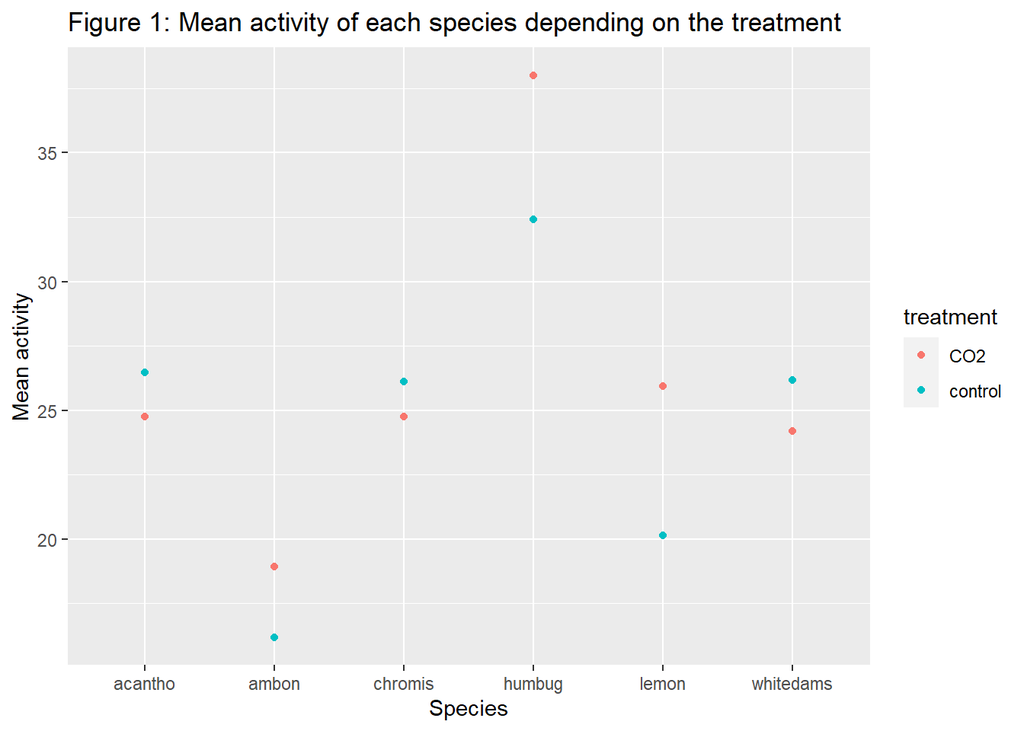

Figure 1: Figure 1: Mean activity of species and treatment

```r
# ggplot figure showing mean activity for each treatment (Control, OA) for each species.
library(ggplot2)
ggplot(unique_g, aes(y = mean, x = species)) + geom_point(aes(colour = treatment)) + labs(title = "Figure 1: Mean activity of each species depending on the treatment", x = "Species", y = "Mean activity")
```

The figure above indicates the changes in fish activity according to levels of CO2 within the water. ‘ancantho’, ‘chromis’ and ‘whitedams’ tends to be more active under the control environment (400-450 uatm of CO2), while ‘ambon’, ‘humbug’ and ‘lemons’ exhibit more activity under elevated CO2 (850-1050 uatm of CO2). Simply looking at this graph, it is inconclusive whether the effects of CO2 affects the level of fish activity, which is coherent with the paper’s evaluation.

# ** Statistical testing: 95% Confidence interval, t-statistics, df and p-value **

```r
# Analysing the mean and standard deviation to determine direction of statistical analysis

  # CO2 treatment analysis
treat <- data_n[which(data_n$treatment == "CO2"),] %>% subset(select = -c(loc, animal_id, sl, size))
mean(treat$activity) #29
```

```
## [1] 29
```

```r
sd(treat$activity) # 13
```

```
## [1] 13
```

```r
  # Control analysis
control <- data_n[which(data_n$treatment == "control"),] %>% subset(select = -c(loc, animal_id, sl, size))
mean(control$activity) # 28
```

```
## [1] 28
```

```r
sd(control$activity) # 13
```

```
## [1] 13
```

```r
  # Both groups have the same standard deviation and very similar mean values, we can utilise the 2 sample t test


### METHOD 1: Doing t test to each species individually
ancantho <- data_n[which(data_n$species == "acantho"),] %>% subset(select = -c(loc, animal_id, sl, size))
ambon <- data_n[which(data_n$species == "ambon"),] %>% subset(select = -c(loc, animal_id, sl, size))
lemon <- data_n[which(data_n$species == "lemon"),] %>% subset(select = -c(loc, animal_id, sl, size))
chromis <- data_n[which(data_n$species == "chromis"),] %>% subset(select = -c(loc, animal_id, sl, size))
humbug <- data_n[which(data_n$species == "humbug"),] %>% subset(select = -c(loc, animal_id, sl, size))
whitedams <- data_n[which(data_n$species == "whitedams"),] %>% subset(select = -c(loc, animal_id, sl, size))

test_ancantho <- t.test(ancantho$activity ~ ancantho$treatment, var.equal = T)
test_ancantho <- test_ancantho[c(1:5)]
  # Difference in mean = 2
  # 95% confidence interval = -4.9 to 1.6
  # t statistic = -1
  # df = 174
  # p-value = 0.3
test_ambon <- t.test(ambon$activity ~ ambon$treatment, var.equal = T)
test_ambon <- test_ambon[c(1:5)]
  # Difference in mean = 1
  # 95% confidence interval = -6.2 to 8.3
  # t statistic = 0.3
  # df = 41
  # p-value = 0.8
test_lemon <- t.test(lemon$activity ~ lemon$treatment, var.equal = T)
test_lemon <- test_lemon[c(1:5)]
  # Difference in mean = 6
  # 95% confidence interval = -0.7 to 13.2
  # t statistic = 2
  # df = 47
  # p-value = 0.08
test_chromis <- t.test(chromis$activity ~ chromis$treatment, var.equal = T)
test_chromis <- test_chromis[c(1:5)]
  # Difference in mean = 1
  # 95% confidence interval = -8.4 to 5.7
  # t statistic = -0.4
  # df = 32
  # p-value = 0.7
test_humbug <- t.test(humbug$activity ~ humbug$treatment, var.equal = T)
test_humbug <- test_humbug[c(1:5)]
  # Difference in mean = 5
  # 95% confidence interval = 0.82 to 9.92
  # t statistic = 2
  # df = 125
  # p-value = 0.02
test_whitedams <- t.test(whitedams$activity ~ whitedams$treatment, var.equal = T)
test_whitedams <- test_whitedams[c(1:5)]
  # Difference in mean = 3
  # 95% confidence interval = -5.9 to 1.6
  # t statistic = -1
  # df = 119
  # p-value = 0.3


### METHOD 2: ANOVA table to assess overall differences
mod1 <- (lm(activity ~ treatment, data = data_n))
summary(mod1)
```

```
##
## Call:
## lm(formula = activity ~ treatment, data = data_n)
##
## Residuals:
##     Min      1Q  Median      3Q     Max
## -27.717  -9.485  -0.232   9.034  29.786
##
## Coefficients:
##                  Estimate Std. Error t value Pr(>|t|)
## (Intercept)        28.742      0.790   36.39   <2e-16 ***
## treatmentcontrol   -0.956      1.093   -0.87     0.38
## ---
## Signif. codes:  0 '***' 0.001 '**' 0.01 '*' 0.05 '.' 0.1 ' ' 1
##
## Residual standard error: 13 on 548 degrees of freedom
## Multiple R-squared:  0.00139,    Adjusted R-squared:  -0.000431
## F-statistic: 0.764 on 1 and 548 DF,  p-value: 0.383
```

To do statistical analysis, we first have to look at the properties of the dataset to find which method would be most accurate for our test case. The mean and standard deviation for the treatment and control groups are 29, 13 and 28, 13 respectively. Because both groups have the same standard deviation (13) and very similar mean values (29 and 28), we can utilise the 2 sample t test.

A 2 sample t test evaluates whether the difference between both group’s responses are statistically significant or not. This test provides a test statistic which follows the student T distribution under the null hypothesis. In our test case, the null hypothesis states that there is no statistical significance between the population means, while the alternative states that there is.

H_0 : There is no statistical significance between the treatment and control population’s mean H_A : The difference of group means is not 0

The second method involves ANOVA for a similar statistical approach. It shows the degree of statistical significance between CO2 (Intercept) and control. The estimate for CO2 is 28.742 while the control group decreases its activity by 0.956 relative to CO2. CO2 has a very low p-value, suggesting statistical significance and a low probability of it occurring by chance. However, the p-value of control is 0.38 which is larger than 0.05. This suggests that we fail to reject the null and shows the overall statistical difference in activity between control and treatment is insignificant, while disregarding species type.